# Rotten Tomatoes sql

Gígja Marín

2024-10-26

```r
# Hleður nauðsynlegum bókasöfnum
library(DBI)
library(RSQLite)
# Tengist SQLite gagnagrunninum
conn <- dbConnect(RSQLite::SQLite(), "Documents/GitHub/capstone-the-north/data2/rotten_tomatoes.db")

# Les gögnin inn úr töflunni í gagnagrunninum til að skoða gögnin ef þú vilt
rotten_tomatoes_data <- dbReadTable(conn, "rotten_tomatoes_movies")
rotten_tomatoes_leo_kate <- dbReadTable(conn, "rotten_tomatoes_movies_dicaprio_winslet")
rotten_tomatoes_actors <- dbReadTable(conn, "movie_actors")
actors_info <- dbReadTable(conn, "actors_info")


# Lokar tengingunni
dbDisconnect(conn)
```

## Búa til töflu bara með myndum sem Leonardo DiCaprio hefur verið í

```r
# Hleður nauðsynlegum bókasöfnum
library(DBI)
library(RSQLite)

# Tengist SQLite gagnagrunninum
conn <- dbConnect(RSQLite::SQLite(), "Documents/GitHub/capstone-the-north/data2/rotten_tomatoes.db")

# Sækir myndir með Leonardo DiCaprio úr rotten_tomatoes_movies_dicaprio_winslet töflunni
leo_movies <- dbGetQuery(conn, "
  SELECT *
  FROM rotten_tomatoes_movies_dicaprio_winslet
  WHERE actors LIKE '%Leonardo DiCaprio%'
")

# Skoða fyrstu línurnar til að staðfesta niðurstöðuna
print(head(leo_movies))
```

```
##             rotten_tomatoes_link              movie_title
## 1        m/10009225-body_of_lies             Body of Lies
## 2   m/1059629-quick_and_the_dead   The Quick and the Dead
## 3 m/1082400-man_in_the_iron_mask The Man in the Iron Mask
## 4       m/1198124-shutter_island           Shutter Island
## 5                    m/11th_hour            The 11th Hour
## 6                      m/aviator              The Aviator
##                                                                                                                                                                                                                                                                                                          …
## 1                                                              CIA agent Roger Ferris (Leonardo DiCaprio) hatches a bold but dangerous plan to capture terrorist Al-Saleem. With the help of Ed Hoffman (Russell Crowe) who is a master of subterfuge, Ferris creates a fake terrorist organization to pr…
## 2                                A mysterious woman gunslinger, Ellen (Sharon Stone), saunters into the town of Redemption looking for revenge. Her father was killed by the town's sadistic mayor, Herod (Gene Hackman), who is in the midst of organizing a quick-draw tournament. The lady enters, joi…
## 3                The former musketeer Athos (John Malkovich) swears vengeance after despotic King Louis XIV (Leonardo DiCaprio) causes the death of his son. Summoning his old comrades Porthos (Gérard Depardieu) and Aramis (Jeremy Irons), he hatches a plan to liberate a shackled prisoner rumored t…
## 4 The implausible escape of a brilliant murderess brings U.S. Marshal Teddy Daniels (Leonardo DiCaprio) and his new partner (Mark Ruffalo) to Ashecliffe Hospital, a fortress-like insane asylum located on a remote, windswept island. The woman appears to have vanished from a locked room, and there …
## 5    The 11th hour is considered the final moment when change is possible. Former Soviet leader Mikhail Gorbachev, theoretical physicist Stephen Hawking and former CIA director R. James Woolsey along with more than 50 other scientists, scholars, and leaders discuss pressing issues facing today's …
## 6           Billionaire and aviation tycoon Howard Hughes (Leonardo DiCaprio) is a successful public figure: a director of big-budget Hollywood films such as "Hell's Angels," a passionate lover of Hollywood leading ladies Katharine Hepburn (Cate Blanchett) and Ava Gardner (Kate Beckinsale), and a…
##                                                                                                                                                                                                                                        critics_consensus
```

[output cut: 62 more lines]

```r
# Lokar tengingunni
dbDisconnect(conn)
```

## Graf sem sýnir samband milli content_rating og Leo_movies

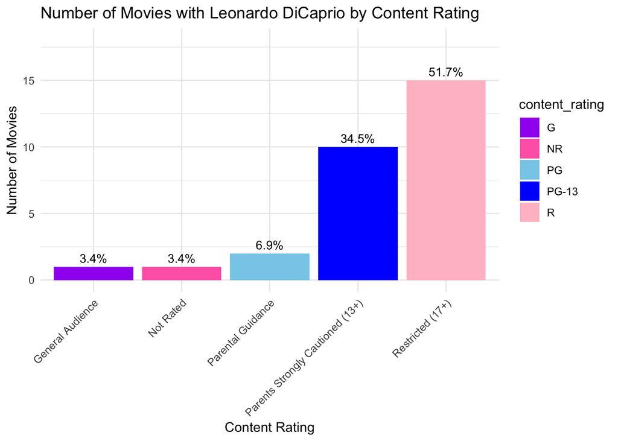

```r
library(ggplot2)
library(dplyr)
# Create a new dataset with the count and percentage of movies for each content rating
leo_movies_count <- leo_movies %>%
  group_by(content_rating) %>%
  summarise(count = n()) %>%
  mutate(percentage = (count / sum(count)) * 100) # Calculate percentages

# Define more descriptive labels
rating_labels <- c("R" = "Restricted (17+)", "G" = "General Audience",
                   "PG-13" = "Parents Strongly Cautioned (13+)",
                   "NR" = "Not Rated", "PG" = "Parental Guidance")

# Draw the bar chart with descriptive labels, angled x-axis text, and percentage labels
ggplot(leo_movies_count, aes(x = content_rating, y = count, fill = content_rating)) +
  geom_bar(stat = "identity") +
  geom_text(aes(label = paste0(round(percentage, 1), "%")),
            vjust = -0.5, size = 3.5) + # Add percentage labels above bars
  scale_fill_manual(values = c("R" = "pink", "G" = "purple",
                               "PG-13" = "blue", "NR" = "hotpink",
                               "PG" = "skyblue")) +
  scale_x_discrete(labels = rating_labels) + # Use descriptive labels
  labs(
    title = "Number of Movies with Leonardo DiCaprio by Content Rating",
    x = "Content Rating",
    y = "Number of Movies"
  ) +
  ylim(0, max(leo_movies_count$count) * 1.2) + # Extend y-axis to 120% of the max count
  theme_minimal() +
  theme(axis.text.x = element_text(angle = 45, hjust = 1)) # Angle x-axis text
```

Nú fyrir Kate Winslet:

```r
# Hleður nauðsynlegum bókasöfnum
library(DBI)
library(RSQLite)

# Tengist SQLite gagnagrunninum
conn <- dbConnect(RSQLite::SQLite(), "Documents/GitHub/capstone-the-north/data2/rotten_tomatoes.db")

# Sækir myndir með Kate Winslet úr rotten_tomatoes_movies_dicaprio_winslet töflunni
kate_movies <- dbGetQuery(conn, "
  SELECT *
  FROM rotten_tomatoes_movies_dicaprio_winslet
  WHERE actors LIKE '%Kate Winslet%'
")

# Skoða fyrstu línurnar til að staðfesta niðurstöðuna
print(head(kate_movies))
```

```
##                         rotten_tomatoes_link
## 1                           m/1075422-hamlet
## 2                             m/1111227-iris
## 3                           m/1113649-enigma
## 4 m/a-mothers-courage-talking-back-to-autism
## 5                           m/a_little_chaos
## 6                        m/all_the_kings_men
##                                                       movie_title
## 1                                                          Hamlet
## 2                                                            Iris
## 3                                                          Enigma
## 4 A Mother's Courage: Talking Back To Autism (Sólskinsdrengurinn)
## 5                                                  A Little Chaos
## 6                                              All The King's Men
##                                                                                                                                                                                                                                                                                                          …
```

[output cut: 69 more lines]

```r
# Lokar tengingunni
dbDisconnect(conn)
```

[figure not shown]

```r
library(ggplot2)
library(dplyr)

# Create a new dataset with the count and percentage of movies for each content rating
kate_movies_count <- kate_movies %>%
  group_by(content_rating) %>%
  summarise(count = n()) %>%
  mutate(percentage = (count / sum(count)) * 100) # Calculate percentages

# Define more descriptive labels
rating_labels <- c("R" = "Restricted (17+)", "G" = "General Audience",
                   "PG-13" = "Parents Strongly Cautioned (13+)",
                   "NR" = "Not Rated", "PG" = "Parental Guidance")

# Draw the bar chart with descriptive labels, angled x-axis text, and percentage labels
ggplot(kate_movies_count, aes(x = content_rating, y = count, fill = content_rating)) +
  geom_bar(stat = "identity") +
  geom_text(aes(label = paste0(round(percentage, 1), "%")),
            vjust = -0.5, size = 3.5) + # Add percentage labels above bars
  scale_fill_manual(values = c("R" = "pink", "G" = "purple",
                               "PG-13" = "blue", "NR" = "hotpink",
                               "PG" = "skyblue")) +
  scale_x_discrete(labels = rating_labels) + # Use descriptive labels
  labs(
    title = "Number of Movies with Leonardo DiCaprio by Content Rating",
    x = "Content Rating",
    y = "Number of Movies"
  ) +
  ylim(0, max(kate_movies_count$count) * 1.2) + # Extend y-axis to 120% of the max count
  theme_minimal() +
  theme(axis.text.x = element_text(angle = 45, hjust = 1)) # Angle x-axis text
```

```r
library(DBI)
library(RSQLite)

# Connect to the SQLite database
conn <- dbConnect(SQLite(), "Documents/GitHub/capstone-the-north/data2/rotten_tomatoes.db")

# Drop the table if it exists
dbExecute(conn, "DROP TABLE IF EXISTS leo_kate_movies;")
```

```
## [1] 0
```

```r
# Run the query to create a new table with movies starring both Leonardo DiCaprio and Kate Winslet
query <- "
  CREATE TABLE leo_kate_movies AS
  SELECT *
  FROM rotten_tomatoes_movies_dicaprio_winslet
  WHERE actors LIKE '%Leonardo DiCaprio%'
    AND actors LIKE '%Kate Winslet%'
"
# Execute the query
dbExecute(conn, query)
```

```
## [1] 0
```

```r
# Optional: Verify the table by fetching data from it
leo_kate_movies <- dbReadTable(conn, "leo_kate_movies")
print(leo_kate_movies)
```

```
##   rotten_tomatoes_link        movie_title
## 1 m/revolutionary_road Revolutionary Road
## 2            m/titanic            Titanic
##                                                                                                                                                                                                                                                                                                          …
## 1 Frank (Leonardo DiCaprio) and April Wheeler (Kate Winslet) always see themselves as far-removed from the conventionality of suburbia. Yet that is exactly what creeps up on them when they buy a house in Connecticut. He toils 10 hours a day in a job he hates, while she, as a 1950s homemaker, year…
## 2   James Cameron's "Titanic" is an epic, action-packed romance set against the ill-fated maiden voyage of the R.M.S. Titanic; the pride and joy of the White Star Line and, at the time, the largest moving object ever built. She was the most luxurious liner of her era -- the "ship of dreams" -- wh…
##                                                                                                                 critics_consensus
## 1     Brilliantly acted and emotionally powerful, Revolutionary Road is a handsome adaptation of Richard Yates' celebrated novel.
## 2 A mostly unqualified triumph for James Cameron, who offers a dizzying blend of spectacular visuals and old-fashioned melodrama.
##   content_rating         genres     directors       authors
## 1              R          Drama    Sam Mendes Justin Haythe
## 2          PG-13 Drama, Romance James Cameron James Cameron
##                                                                                                                                                                                                                                                                                                          …
## 1                                                                                                                                                                                                                                                                                                        …
## 2 Leonardo DiCaprio, Kate Winslet, Billy Zane, Kathy Bates, Frances Fisher, Bill Paxton, Bernard Hill, Jonathan Hyde, Victor Garber, David Warner, Danny Nucci, Jonny Phillips, Ioan Gruffudd, Suzy Amis, Bernard Fox, Lewis Abernathy, Nicholas Cascone, Ewan Stewart, Mark Lindsay Chapman, Anatoly M. …
##   original_release_date streaming_release_date runtime production_company
## 1            2008-12-15             2013-08-01     119  Paramount Vantage
## 2            1997-12-19             2014-06-01     195 Paramount Pictures
##   tomatometer_status tomatometer_rating tomatometer_count audience_status
## 1              Fresh                 67               212         Upright
## 2    Certified-Fresh                 89               192         Upright
##   audience_rating audience_count tomatometer_top_critics_count
## 1              71         106938                            48
## 2              69       35797635                            62
##   tomatometer_fresh_critics_count tomatometer_rotten_critics_count movie_id
## 1                             143                               69    12504
## 2                             171                               21    16298
```

```r
# Close the database connection
dbDisconnect(conn)
```

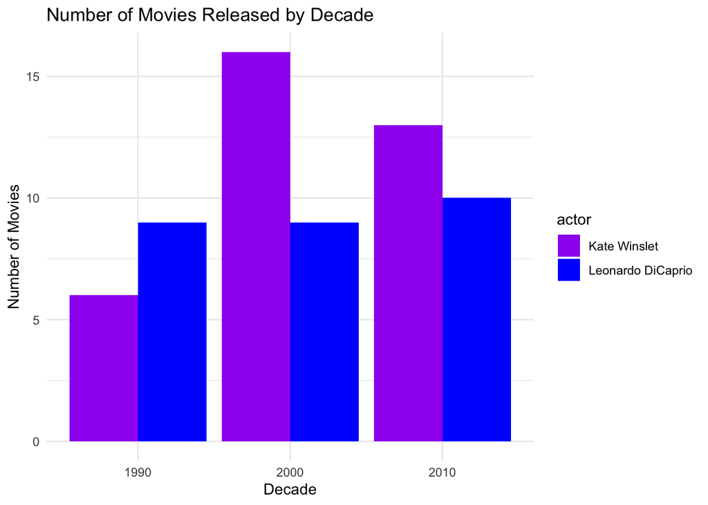

```r
library(DBI)
library(RSQLite)
library(dplyr)
library(ggplot2)

# Helper function to extract the decade
extract_decade <- function(date) {
  year <- as.numeric(substr(date, 1, 4))
  decade <- floor(year / 10) * 10
  return(decade)
}

# Filter out rows with NA in original_release_date and add a decade column to both datasets
leo_movies2 <- leo_movies %>%
  filter(!is.na(original_release_date)) %>%  # Remove NA values
  mutate(decade = extract_decade(original_release_date)) %>%
  group_by(decade) %>%
  summarise(count = n(), actor = "Leonardo DiCaprio")

kate_movies2 <- kate_movies %>%
  filter(!is.na(original_release_date)) %>%  # Remove NA values
  mutate(decade = extract_decade(original_release_date)) %>%
  group_by(decade) %>%
  summarise(count = n(), actor = "Kate Winslet")

# Combine the two datasets and remove NA decades
movies_decades <- bind_rows(leo_movies2, kate_movies2) %>%
  filter(!is.na(decade))  # Remove rows with NA in the decade column

# Plot the data
ggplot(movies_decades, aes(x = factor(decade), y = count, fill = actor)) +
  geom_bar(stat = "identity", position = "dodge") +
  labs(
    title = "Number of Movies Released by Decade",
    x = "Decade",
    y = "Number of Movies"
  ) +
  scale_fill_manual(values = c("Leonardo DiCaprio" = "blue", "Kate Winslet" = "purple")) +
  theme_minimal()
```

# Fleiri hugmyndir

Gætum reynt að komast að því hvor er betri leikari samkvæmt út frá gögnunum okkar.

- Skoða starfsferil þeirra, vinsældir, gagnrýni og áhorfendamat.

### Samanburður á Tomatometer og Audience Rating:

- Bera saman meðaltal þeirra í tomatometer_rating og audience_rating til að sjá hver fær hærri einkunnir frá gagnrýnendum og áhorfendum.
- Gera súlurit sem ber saman meðaleinkunnir, skipt eftir tomatometer (gagnrýnendur) og audience (áhorfendur).

#### Þróun einkunna yfir tíma:

- Skoða hvernig einkunnir hvers leikarans hafa þróast yfir árin til að greina stefnur (t.d. hvort einkunnir hafi batnað með mismunandi hlutverkum).
- Gera línurit sem sýnir meðaltal tomatometer_rating og audience_rating yfir áratugi fyrir hvern leikara.

#### Frammistaða eftir tegundum (Genre):

- Greina í hvaða genre hver leikari fær hæstu einkunnir.
- Töflur: Meðaleinkunnir tomatometer_rating og audience_rating fyrir hverja tegund, eftir leikara.
- Gera súlurit eða side by side súlurit eftir tegund til að auðvelda samanburð.

#### Mismunur á gagnrýnenda- og áhorfendaeinkunnum:

Skoða myndir með mikinn mun á milli tomatometer_rating og audience_rating. Þetta gæti varpað ljósi á hvor leikarinn á fleiri “kult” myndir eða myndir sem gagnrýnendur elska meira en áhorfendur.

Töflur: Myndir með mesta mismuninn í einkunnum fyrir hvern leikara. Gröf: Dreifirit af tomatometer_rating á móti audience_rating með merkjum fyrir mikilvægar myndir.

#### Hæst og lægst metnu myndir:

Búa til lista yfir hæst og lægst metnu myndir hvers leikarans samkvæmt bæði gagnrýnendum og áhorfendum. Töflur: Topp 5 og neðstu 5 myndir eftir tomatometer_rating og audience_rating. Gert mögulega eh graf útúr því líka.

#### Skoða myndirnar sem þau leika í saman:

Kanna hversu oft þau hafa leikið saman og hvort þær myndir fá hærri einkunnir eða meiri vinsældir.

Gröf: Dreifirit af myndum með tomatometer_rating á x-ás og audience_rating á y-ás.

Nota original_release_date til að sýna hápunkta í ferlinum eða merkjanlegar breytingar (t.d. þegar DiCaprio eða Winslet unnu Óskarsverðlaun).

Gröf: Tímalínurit eða merkt línurit sem sýnir myndir þeirra með áherslu á mikilvæga áfanga.